# lab3_notebook

## **My first ML Model using [California Housing Prices Dataset](https://www.kaggle.com/datasets/camnugent/california-housing-prices)**

### **1. REPORT DESCRIPTION**

This report contains trends based on the 1990 California census. The dataset is of houses found in district of California and statistics about it. It was chosen for this report because it is beginner friendly and helpful in understanding the basics of machine learning. This report will show linear regression between the *median house value* and each of the following independent variables:

- *median income*
- *population*
- *number of households*

Based on the report of comparison between median house value and above 3 variables, we will find which model performs the best in predicting house value.

```python
import pandas as pd
import seaborn as sns
import matplotlib.pyplot as plt
from sklearn.linear_model import LinearRegression
from sklearn.metrics import mean_squared_error, mean_absolute_error
```

### **2. LOADING THE DATA**

The dataset is placed inside data folder of github repository. Loading the data from the repository into pandas.

```python
# Load the dataset
housing_data = pd.read_csv("https://raw.githubusercontent.com/praiselydia/CSCN8010-labs/main/data/housing.csv")
```

### **3. EXPLATORY DATA ANALYSIS (EDA)**

#### **3.1 EXPLORE STATISTICS**

```python
print(housing_data.describe())
```

```
          longitude      latitude  housing_median_age   total_rooms
count  20640.000000  20640.000000        20640.000000  20640.000000  \
mean    -119.569704     35.631861           28.639486   2635.763081
std        2.003532      2.135952           12.585558   2181.615252
min     -124.350000     32.540000            1.000000      2.000000
25%     -121.800000     33.930000           18.000000   1447.750000
50%     -118.490000     34.260000           29.000000   2127.000000
75%     -118.010000     37.710000           37.000000   3148.000000
max     -114.310000     41.950000           52.000000  39320.000000

       total_bedrooms    population    households  median_income
count    20433.000000  20640.000000  20640.000000   20640.000000  \
mean       537.870553   1425.476744    499.539680       3.870671
std        421.385070   1132.462122    382.329753       1.899822
min          1.000000      3.000000      1.000000       0.499900
25%        296.000000    787.000000    280.000000       2.563400
50%        435.000000   1166.000000    409.000000       3.534800
75%        647.000000   1725.000000    605.000000       4.743250
max       6445.000000  35682.000000   6082.000000      15.000100

       median_house_value
count        20640.000000
mean        206855.816909
std         115395.615874
min          14999.000000
25%         119600.000000
50%         179700.000000
75%         264725.000000
max         500001.000000
```

#### **3.2 DESCRIBE THE VARIABLES**

Review on these statistics:

The four variables used to plot in this report are median_house value, median_income, population and households. Based on the dataset description, the mean values of the columns fall close to the average value or nearer to the minimum value which says most of the population buy houses that have value from minimum to the average value and very less population buy houses that are worth more.

| Column Name | Min | Max | Mean |
| --- | --- | --- | --- |
| median_house_value | 14999 | 500001 | 206855.816909 |
| median_income | 0.499900 | 15.000100 | 3.870671 |
| population | 3 | 35682 | 1425.476744 |
| households | 1 | 6082 | 499.539680 |

The only issue is population is high only in some areas and some areas have very less population. So the house value is not evenly distributed among all areas. But still house value hits maximum where there is very less population.

#### **3.3 SEABORN SCATTER PLOTS**

a. Scatter plot between `median_house_value` and `median_income`

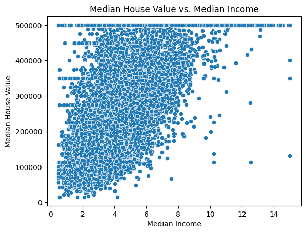

```python
sns.scatterplot(x='median_income', y='median_house_value', data=housing_data)
plt.title('Median House Value vs. Median Income')
plt.xlabel('Median Income')
plt.ylabel('Median House Value')
plt.show()
```

**Plot (a) Insight:**

Median house value has a linear increase as the Median Income increases. There are some points that are out of the place but majority of the points fall in and around a line growing gradually till it reaches the maximum value of 500001.

b. Scatter plot between `median_house_value` and `population`

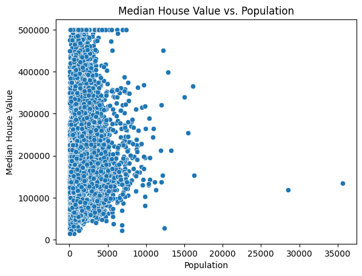

```python
sns.scatterplot(x='population', y='median_house_value', data=housing_data)
plt.title('Median House Value vs. Population')
plt.xlabel('Population')
plt.ylabel('Median House Value')
plt.show()
```

c. Scatter plot between `median_house_value` and `Number of households`

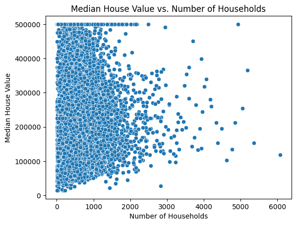

```python
sns.scatterplot(x='households', y='median_house_value', data=housing_data)
plt.title('Median House Value vs. Number of Households')
plt.xlabel('Number of Households')
plt.ylabel('Median House Value')
plt.show()
```

**Plot (c) Insight:**

There is no proper proportion between number of houses and the median house value. The house value is not related to the number of households.

### **4. LINEAR REGRESSIONS (FITTING)**

a. Linear regression between `median_house_value` and `median_income`

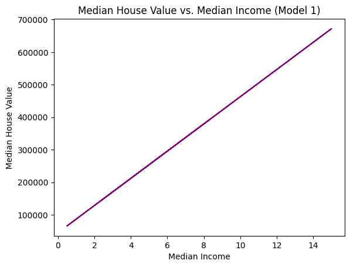

```python
model1 = LinearRegression().fit(housing_data[['median_income']], housing_data[['median_house_value']])
pred1 = model1.predict(housing_data[['median_income']])
plt.plot(housing_data['median_income'], pred1, color='purple')
plt.title('Median House Value vs. Median Income (Model 1)')
plt.xlabel('Median Income')
plt.ylabel('Median House Value')
plt.show()
```

b. Linear regression between `median_house_value` and `population`

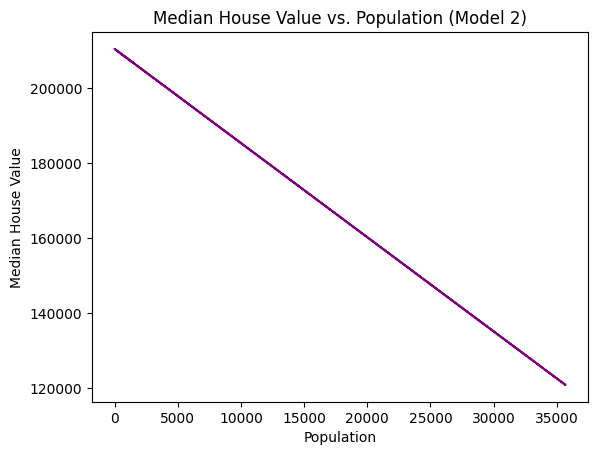

```python
model2 = LinearRegression().fit(housing_data[['population']], housing_data[['median_house_value']])
pred2 = model2.predict(housing_data[['population']])
plt.plot(housing_data['population'], pred2, color='purple')
plt.title('Median House Value vs. Population (Model 2)')
plt.xlabel('Population')
plt.ylabel('Median House Value')
plt.show()
```

c. Linear regression between `median_house_values` and `number_of_households`

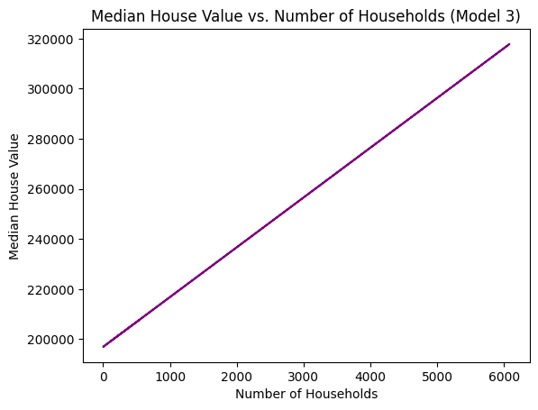

```python
model3 = LinearRegression().fit(housing_data[['households']], housing_data[['median_house_value']])
pred3 = model3.predict(housing_data[['households']])
plt.plot(housing_data['households'], pred3, color='purple')
plt.title('Median House Value vs. Number of Households (Model 3)')
plt.xlabel('Number of Households')
plt.ylabel('Median House Value')
plt.show()
```

### **5. MODEL SUMMARY TABLE**

```python
# Function to return model summary
def run_summary(X, y):
    # Fit the model
    model = LinearRegression().fit(X, y)

    # Predict
    y_pred = model.predict(X)

    # Calculate metrics
    mse = mean_squared_error(y, y_pred)
    mae = mean_absolute_error(y, y_pred)

    # Return model summary
    return {
        'intercept': model.intercept_,
        'slope': model.coef_[0],
        'MSE': mse,
        'MAE': mae,
    }
```

```python
# Summary 1: Median Income vs. Median House Value
model1_summary = run_summary(housing_data[['median_income']], housing_data['median_house_value'])

# Summary 2: Population vs. Median House Value
model2_summary = run_summary(housing_data[['population']], housing_data['median_house_value'])

# Summary 3: Number of Households vs. Median House Value
model3_summary = run_summary(housing_data[['households']], housing_data['median_house_value'])
```

```python
# Summary table
summary_table = pd.DataFrame({
    'Model': ['median_house_value vs median_income', 'median_house_value vs population', 'median_house_value vs households'],
    'Intercept': [model1_summary['intercept'], model2_summary['intercept'], model3_summary['intercept']],
    'Slope': [model1_summary['slope'], model2_summary['slope'], model3_summary['slope']],
    'Mean Squared Error (MSE)': [model1_summary['MSE'], model2_summary['MSE'], model3_summary['MSE']],
    'Mean Absolute Error (MAE)': [model1_summary['MAE'], model2_summary['MAE'], model3_summary['MAE']]
})

print(summary_table)
```

```
                                 Model      Intercept         Slope
0  median_house_value vs median_income   45085.576703  41793.849202  \
1     median_house_value vs population  210436.262076     -2.511753
2     median_house_value vs households  196928.577162     19.872775

   Mean Squared Error (MSE)  Mean Absolute Error (MAE)
0              7.011312e+09               62625.933791
1              1.330741e+10               91153.820095
2              1.325778e+10               90802.743243
```

### **6. LINE AND SCATTER PLOT TOGETHER**

Model 1 : Median House Value vs. Median Income

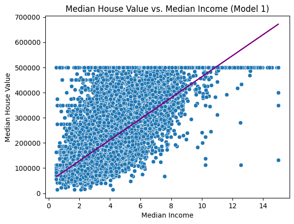

```python
sns.scatterplot(x='median_income', y='median_house_value', data=housing_data)
plt.plot(housing_data['median_income'], pred1, color='purple')
plt.title('Median House Value vs. Median Income (Model 1)')
plt.xlabel('Median Income')
plt.ylabel('Median House Value')
plt.show()
```

Model 2 : Median House Value vs. Population

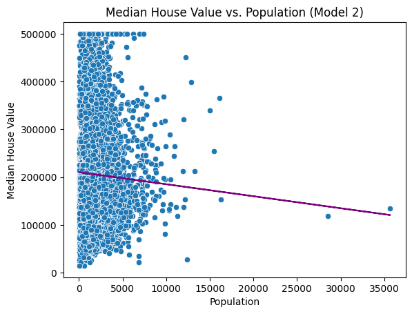

```python
sns.scatterplot(x='population', y='median_house_value', data=housing_data)
plt.plot(housing_data['population'], pred2, color='purple')
plt.title('Median House Value vs. Population (Model 2)')
plt.xlabel('Population')
plt.ylabel('Median House Value')
plt.show()
```

Model 3 : Median House Value vs. Number of Households

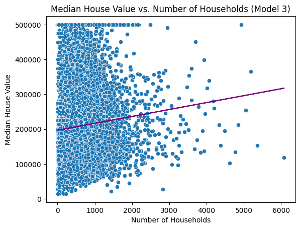

```python
sns.scatterplot(x='households', y='median_house_value', data=housing_data)
plt.plot(housing_data['households'], pred3, color='purple')
plt.title('Median House Value vs. Number of Households (Model 3)')
plt.xlabel('Number of Households')
plt.ylabel('Median House Value')
plt.show()
```

### **7. CONCLUSION**

Based on the Mean Square Error and Mean Absolute Error obtained, Model 1 (`median_house_value vs median_income`) predicts better than Model 2 (`median_house_value vs population`) and Model 3 (`median_house_value vs households`), since it has smaller values. Model 1 and Model 3 show positive slope, which means that as the median_income and number of households increases respectively, the median_house_value also increases. Whereas, Model 2 shows that as the population increases, median_house_value decreases. The intercepts of Model 1, 2 and 3 give the value of median_house_value when median_income, population and number of households are zero respectively. On the whole, the median income appears to be the most significant predictor of median house values, followed by the number of households, while the population has a less significant impact.